# Salk Project CO₂ Data Analysis

Adrianne Seiden

08/13/2025

# Overview

### Sample collection

CO₂ gas samples were collected from incubation jars and intact pots at UC Merced between October 29, 2024 and July 28, 2025. Both jars and pots were incubated in Sustainability Research and Engineering (SRE), room 450. For each sampling, pots were capped with a PVC chamber for approximately 60 minutes and jars were sealed with screw-on lids for approximately 24 hours. Headspace gas was sampled by hand (60 mL ea) and injected into evacuated 12mL Labco Exetainer vials. About 48 mL of sample was used to flush the vials, which were then overpressurized with the remaining 12mL.

### Analysis

Samples were analyzed at UC Davis’s Stable Isotope Facility (SIF), using a Thermo Scientific Gas Bench interfaced to a Delta V Plus IRMS (ThermoScientific, Bremen, Germany). δ¹³C<sub>VPDB</sub> (‰) and at-% ¹³C are raw values, from SIF. CO₂ (ppm) - Blank and CO₂ Flux are calculated values.

### CO₂ (ppm) - Blank

For the first batch (1 - 629), SIF lab air CO₂ concentrations are used as the blank value because no samples of SRE 450 lab air were analyzed with these samples. For the second batch, 6 samples of the air in room 450 were included, and an average of these values (within 1 standard deviation, n = 5) is used as the blank value. This may need to be revised for consistency.

### CO₂ Flux

Since the jars had a known and constant amount of soil, flux was calculated as μg CO₂-C · g-soil⁻¹ · minute⁻¹. Since pots had variable amounts of soil (following destructive sampling of ~1/4 wedges every 10 weeks), and the chambers did not cover the entire pot, flux was calculated by approximating the headspace volume inside the chamber (μg CO₂-C · cm[V/A]⁻¹ · minute⁻¹). Flux calculations are based on Robertson, G. P., Blair, J. M., Groffman, P. M., Harris, D., Holland, E., Nadelhoffer, K., & Wedin, D. (1999). Soil carbon and nitrogen availability: Nitrogen mineralization, nitrification, and soil respiration potentials. In G. P. Robertson, C. S. Bledsoe, D. C. Coleman, & P. Sollins (Eds.), Standard Soil Methods for Long-Term Ecological Research. Oxford University Press. download link

# Jar data

## Reading data & summarizing

The following code cell re-imports data from “Compiled_CO2_data.xlsx”, merges wk0 root elemental-analysis values by crop for C_pct and by crop/isotope for 13C_at-pct, estimates root C mass for each jar from the crop-level C_pct, and generates summary statistics (mean, standard deviation, minimum, maximum and count), grouped by crop, isotope and sampling week for δ¹³C<sub>VPDB</sub> (‰), at-% ¹³C, CO₂ (ppm) - Blank, and flux (μg CO₂-C · g-soil⁻¹ · minute⁻¹). It saves these statistics as a new tab, “Jars_Summary_Stats”, in the spreadsheet “Compiled_CO2_data.xlsx”.

```python
import os
import pandas as pd
import matplotlib.pyplot as plt
import seaborn as sns
import numpy as np
import openpyxl

box_base = os.environ.get('BOX_BASE')
if box_base is None:
    raise ValueError("BOX_BASE environment variable is not set!")

excel_path = os.path.join(box_base, "Salk Institute Project/AKS Salk files/CO2 data/Compiled_CO2_data.xlsx")

# Read the 'Jars' tab from the Excel file
try:
    df = pd.read_excel(excel_path, sheet_name='Jars')
    print("Excel file loaded successfully!")
except Exception as e:
    print(f"Error loading Excel file: {e}")
    print(f"File exists check: {os.path.exists(excel_path)}")
    print(f"Directory exists check: {os.path.exists(os.path.dirname(excel_path))}")
    # Don't exit, just raise the error so we can see it
    raise e

# Read wk0 root elemental-analysis data and average replicates by crop for C_pct_wk0
# and by crop/isotope for 13C_at-pct.
root_data_path = os.path.join(box_base, "Salk Institute Project/AKS Salk files/CO2 data/plant-root-CN.csv")
root_df = pd.read_csv(root_data_path)
root_df['week'] = pd.to_numeric(root_df['week'], errors='coerce')
root_df = root_df.loc[root_df['week'] == 0].copy()
root_df['isotope'] = pd.to_numeric(root_df['isotope'].astype(str).str.extract(r'([0-9]+)')[0], errors='coerce')
root_df = root_df.dropna(subset=['crop', 'isotope', 'C_pct', '13C_at-pct'])
root_df['isotope'] = root_df['isotope'].astype(int)

root_crop_summary = root_df.groupby('crop', as_index=False).agg({
    'C_pct': 'mean',
    'Sample ID': 'count'
}).rename(columns={'C_pct': 'C_pct_wk0', 'Sample ID': 'wk0_root_n_crop'})

root_isotope_summary = root_df.groupby(['crop', 'isotope'], as_index=False).agg({
    '13C_at-pct': 'mean',
    'Sample ID': 'count'
}).rename(columns={'Sample ID': 'wk0_root_n_isotope'})

df = df.drop(columns=['C_pct_wk0', '13C_at-pct', 'wk0_root_n', 'wk0_root_n_crop', 'wk0_root_n_isotope', 'est-root-C_mg'], errors='ignore')
df = df.merge(root_crop_summary, on=['crop'], how='left')
df = df.merge(root_isotope_summary, on=['crop', 'isotope'], how='left')
df['est-root-C_mg'] = np.where(
    df['T0_root-mass_mg'].fillna(0).eq(0),
    0,
    df['T0_root-mass_mg'] * df['C_pct_wk0'] / 100.0
)

try:
    with pd.ExcelWriter(excel_path, engine='openpyxl', mode='a', if_sheet_exists='replace') as writer:
        df.to_excel(writer, sheet_name='Jars', index=False)
    print("Updated 'Jars' tab saved with wk0 root elemental-analysis values and est-root-C_mg")
except Exception as e:
    print(f"Error saving updated Jars sheet: {e}")

print("\nMerged wk0 root elemental-analysis preview:")
print(df[['crop', 'isotope', 'C_pct_wk0', '13C_at-pct', 'T0_root-mass_mg', 'est-root-C_mg']].head(10))

# # Display the first few rows to verify data
# print("\nFirst 5 rows of the dataframe:")
# print(df.head())

# # Check column names
# print("\nColumn names:")
# print(df.columns.tolist())

# Convert isotope to integer format (removing decimals)
df['isotope'] = df['isotope'].fillna(-1)  # Replace NaN with -1 temporarily
df['isotope'] = df['isotope'].astype(int)  # Convert to integer
df.loc[df['isotope'] == -1, 'isotope'] = np.nan  # Convert -1 back to NaN if needed

# Remove rows with NaN values in key columns
columns_to_analyze = ['δ13CVPDB (‰)', 'at-% 13C', 'CO2 (ppm) - Blank', 'Flux (μg CO2-C/g-soil/minute)']
df_clean = df.dropna(subset=['crop', 'isotope', 'sampling_wk'] + columns_to_analyze)

# print(f"\nRemoved {len(df) - len(df_clean)} rows with NaN values")
# print(f"Remaining rows: {len(df_clean)}")

# Generate summary statistics grouped by crop, isotope, and sampling_wk
summary_stats = df_clean.groupby(['crop', 'isotope', 'sampling_wk'])[columns_to_analyze].agg(
    ['mean', 'std', 'min', 'max', 'count']
)

# Save the summary statistics to a new tab in the existing Excel file
try:
    with pd.ExcelWriter(excel_path, engine='openpyxl', mode='a', if_sheet_exists='replace') as writer:
        summary_stats.to_excel(writer, sheet_name='Jars_Summary_Stats')
    print("\nSummary statistics saved to 'Jars_Summary_Stats' tab in the existing Excel file")
except Exception as e:
    print(f"Error saving to Excel file: {e}")

# Print a preview of the summary statistics
print("\nSummary Statistics Preview:")
print(summary_stats.head())
```

```
> Excel file loaded successfully!
> Updated 'Jars' tab saved with wk0 root elemental-analysis values and est-root-C_mg
>
> Merged wk0 root elemental-analysis preview:
>       crop  isotope  C_pct_wk0  13C_at-pct  T0_root-mass_mg  est-root-C_mg
> 0     rice       12  26.983450    1.075457             76.1      20.534405
> 1     rice       12  26.983450    1.075457             82.4      22.234363
> 2     rice       12  26.983450    1.075457             73.0      19.697918
> 3     rice       12  26.983450    1.075457             73.9      19.940769
> 4      soy       12  17.222053         NaN             74.1      12.761542
> 5      soy       12  17.222053         NaN             70.3      12.107104
> 6      soy       12  17.222053         NaN             72.7      12.520433
> 7      soy       12  17.222053         NaN             72.5      12.485989
> 8  noPlant       12        NaN         NaN              0.0       0.000000
> 9  noPlant       12        NaN         NaN              0.0       0.000000
>
> Summary statistics saved to 'Jars_Summary_Stats' tab in the existing Excel file
>
> Summary Statistics Preview:
>                             δ13CVPDB (‰)            ... Flux (μg CO2-C/g-soil/minute)
>                                     mean       std  ...                           max count
> crop    isotope sampling_wk                         ...
> noPlant 12.0    1             -22.466808  0.485415  ...                      0.003037    16
>                 2             -19.869625  4.150075  ...                      0.002117    12
>                 3             -20.485766  2.446432  ...                      0.002454    12
>                 4             -20.051849  1.745761  ...                      0.001479    12
>                 5             -20.730754  0.828577  ...                      0.001251    12
>
> [5 rows x 20 columns]
```

### Jar cumulative flux CSV

The following code calculates cumulative CO<sub>2</sub>-C for each jar at every sampling timepoint using trapezoidal integration on the jar-level flux series, then saves the result as a CSV file.

```python
import os
import numpy as np
import pandas as pd

flux_col = 'Flux (μg CO2-C/g-soil/minute)'
csv_output_path = os.path.join(
    box_base,
    'Salk Institute Project/AKS Salk files/CO2 data/jars_cumulative_flux_by_timepoint.csv'
)

required_cols = ['jar_num', 'crop', 'isotope', 'sampling_wk', 'sampling_date', flux_col]
jar_flux = df_clean.dropna(subset=required_cols).copy()
jar_flux = jar_flux.sort_values(['jar_num', 'sampling_wk', 'sampling_date'])

jar_cumulative_rows = []

for (jar_num, crop, isotope), group in jar_flux.groupby(['jar_num', 'crop', 'isotope']):
    group = group.sort_values(['sampling_wk', 'sampling_date']).copy()
    weeks = group['sampling_wk'].to_numpy(dtype=float)
    fluxes = group[flux_col].to_numpy(dtype=float)
    cumulative_flux = np.zeros(len(group), dtype=float)

    for i in range(1, len(group)):
        delta_t = weeks[i] - weeks[i - 1]
        trap_area = (fluxes[i - 1] + fluxes[i]) / 2.0 * delta_t
        cumulative_flux[i] = cumulative_flux[i - 1] + trap_area

    group['cumulative_flux_trapz'] = cumulative_flux
    group['cumulative_flux_timepoint'] = np.arange(1, len(group) + 1)
    jar_cumulative_rows.append(
        group[[
            'jar_num',
            'crop',
            'isotope',
            'sampling_wk',
            'sampling_date',
            flux_col,
            'cumulative_flux_trapz',
            'cumulative_flux_timepoint'
        ]]
    )

jar_cumulative_df = pd.concat(jar_cumulative_rows, ignore_index=True) if jar_cumulative_rows else pd.DataFrame()

try:
    jar_cumulative_df.to_csv(csv_output_path, index=False)
    print(f"Saved jar cumulative flux CSV to: {csv_output_path}")
    print("\nJar cumulative flux preview:")
    print(jar_cumulative_df.head(10).to_string())
except Exception as e:
    print(f"Error saving jar cumulative flux CSV: {e}")
```

```
> Saved jar cumulative flux CSV to: C:/Users/adria/Box\Salk Institute Project/AKS Salk files/CO2 data/jars_cumulative_flux_by_timepoint.csv
>
> Jar cumulative flux preview:
>    jar_num     crop  isotope  sampling_wk sampling_date  Flux (μg CO2-C/g-soil/minute)  cumulative_flux_trapz  cumulative_flux_timepoint
> 0        1     rice     12.0            1    2024-12-31                       0.001306                    0.0                          1
> 1        2     rice     12.0            1    2024-12-31                       0.002414                    0.0                          1
> 2        3     rice     12.0            1    2024-12-31                       0.002505                    0.0                          1
> 3        4     rice     12.0            1    2024-12-31                       0.003927                    0.0                          1
> 4        5      soy     12.0            1    2024-12-31                       0.001946                    0.0                          1
> 5        6      soy     12.0            1    2024-12-31                       0.002024                    0.0                          1
> 6        7      soy     12.0            1    2024-12-31                       0.002554                    0.0                          1
> 7        8      soy     12.0            1    2024-12-31                       0.001539                    0.0                          1
> 8       13  noPlant     12.0            1    2024-12-31                       0.002334                    0.0                          1
> 9       14  noPlant     12.0            1    2024-12-31                       0.001315                    0.0                          1
```

## Plotting δ<sup>13</sup>C<sub>VPDB</sub> & CO<sub>2</sub> flux (jars)

The following code plots δ<sup>13</sup>C<sub>VPDB</sub> (‰) vs Sampling week and Flux (μg CO<sub>2</sub>-C ⋅ g-soil<sup>-1</sup> ⋅ minute<sup>-1</sup>) vs Sampling week as subplots on one figure. It saves the figure as a PNG file called “jars_analysis_plots_VPDB”.

```
>
> Plots saved to 'jars_analysis_plots_VPDB.png'
```

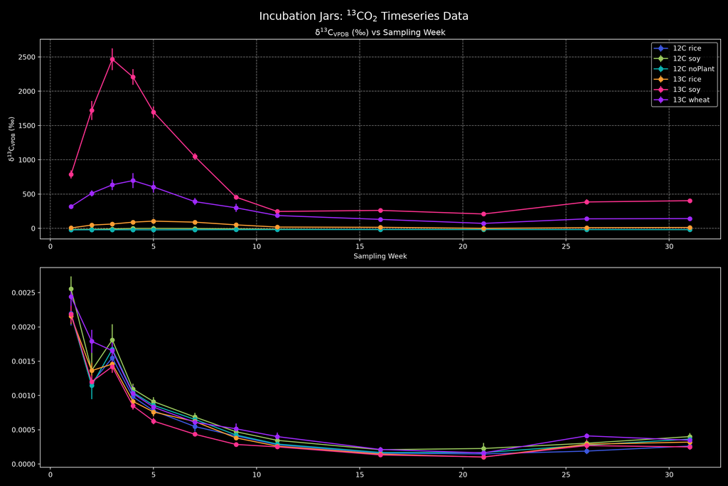

```python
import pandas as pd
import matplotlib
matplotlib.use('Agg')
import matplotlib.pyplot as plt
import seaborn as sns
import numpy as np
# Enable the dark_background style sheet
plt.style.use('dark_background')
# Create figure for plotting
fig=plt.figure(figsize=(15, 10));
fig.suptitle(r'Incubation Jars: $\mathrm{^{13}CO_{2}}$ Timeseries Data', fontsize=16);
# Get unique combinations of crop and isotope
crop_isotope_combinations = df_clean[['crop', 'isotope']].drop_duplicates()

# Create a color palette for consistent colors across plots
# Use a different approach with a simple list of colors
#num_combinations = len(crop_isotope_combinations)
#colors = sns.color_palette('husl', num_combinations)
colors = ['#3C57DE', '#98C65D', '#0CB2AF','#FC9D33', '#FE318E','#9F29FF']   # blue, green, teal, orange, pink, purple


# Creating Plot 1: δ13CVPDB (‰) vs sampling_week
plt.subplot(2, 1, 1);

# Plot each crop & root_isotope combination as a separate series
for i, (_, row) in enumerate(crop_isotope_combinations.iterrows()):
    crop = row['crop']
    isotope = int(row['isotope'])  # Convert to integer to remove decimal

    # Filter data for this combination
    subset = df_clean[(df_clean['crop'] == crop) & (df_clean['isotope'] == isotope)]

    # Calculate mean and standard error for each sampling_wk
    grouped = subset.groupby('sampling_wk')['δ13CVPDB (‰)'].agg(['mean', 'sem']).reset_index()

    # Plot the mean values with predefined color from index
    plt.errorbar(grouped['sampling_wk'], grouped['mean'], yerr=grouped['sem'],
                 marker='o', linestyle='-', label=f"{isotope}C {crop}", color=colors[i]);

plt.xlabel('Sampling Week');
plt.ylabel(r'$\mathrm{δ^{13}C_{VPDB}}$ (‰)');
plt.title(r'$\mathrm{δ^{13}C_{VPDB}}$ (‰) vs Sampling Week');
plt.grid(True, linestyle='--', alpha=0.48);
plt.legend();

# Creating Plot 2: Flux (μg CO2-C/g-soil/minute) vs sampling_week
plt.subplot(2, 1, 2);

# Plot each crop & root_isotope combination as a separate series
for i, (_, row) in enumerate(crop_isotope_combinations.iterrows()):
    crop = row['crop']
    isotope = int(row['isotope'])  # Convert to integer to remove decimal

    # Filter data for this combination
    subset = df_clean[(df_clean['crop'] == crop) & (df_clean['isotope'] == isotope)]

    # Calculate mean and standard error for each sampling_week
    grouped = subset.groupby('sampling_wk')['Flux (μg CO2-C/g-soil/minute)'].agg(['mean', 'sem']).reset_index()

    # Plot the mean values with predefined color from index
    plt.errorbar(grouped['sampling_wk'], grouped['mean'], yerr=grouped['sem'],
                 marker='o', linestyle='-', label=f"{isotope}C {crop}", color=colors[i]);

# Adjust layout and save figure
plt.tight_layout()
plots_folder = os.path.join(box_base, "Salk Institute Project/AKS Salk files/CO2 data/Plots/")
plt.savefig(os.path.join(plots_folder, 'jars_analysis_plots_VPDB.png'), dpi=300)
print("\nPlots saved to 'jars_analysis_plots_VPDB.png'")

# Show the plots
plt.show()
```

## Plotting atom % <sup>13</sup>C & CO<sub>2</sub> flux (jars)

The following code plots atom %<sup>13</sup>C vs Sampling week and Flux (μg CO<sub>2</sub>-C ⋅ g-soil<sup>-1</sup> ⋅ minute<sup>-1</sup>) vs Sampling week as subplots on one figure. It saves the figure as a PNG file called “jars_analysis_plots_at-pct”. I wrote this after noticing that JP presents isotope data in atom % rather than δ<sup>13</sup>C<sub>VPDB</sub> (‰).

```
>
> Plots saved to 'jars_analysis_plots_at-pct.png'
```

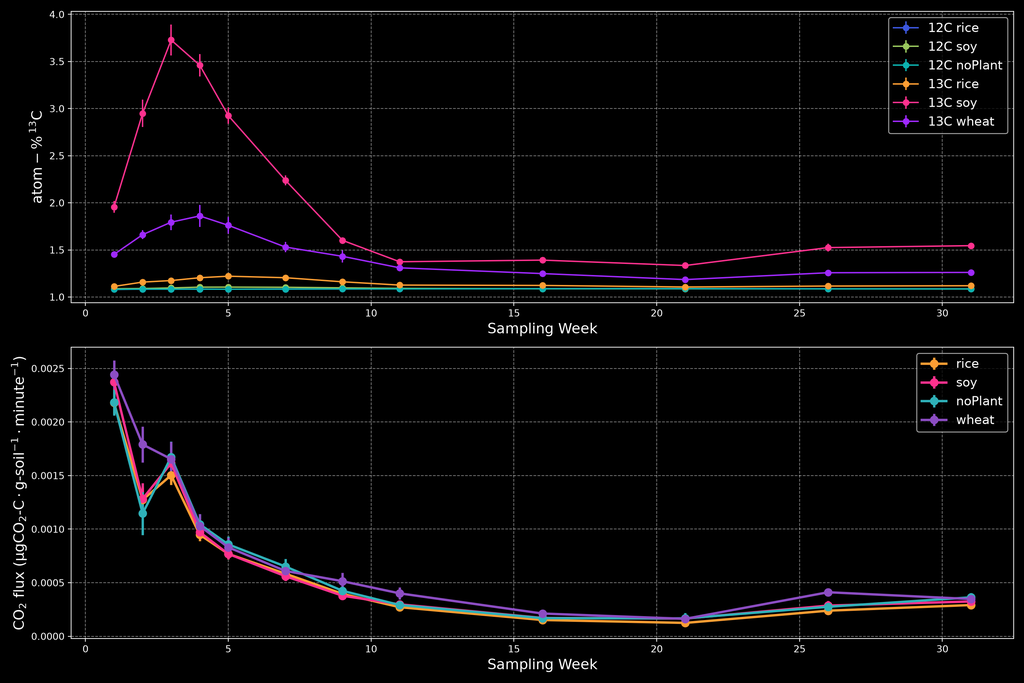

```python
import pandas as pd
import matplotlib.pyplot as plt
import seaborn as sns
import numpy as np

# Create figure for plotting
fig1=plt.figure(figsize=(15, 10))
# fig1.suptitle(r'Incubation Jars: $\mathrm{^{13}CO_{2}}$ Timeseries Data', fontsize=16);
# Get unique combinations of crop and isotope
crop_isotope_combinations = df_clean[['crop', 'isotope']].drop_duplicates()

# Create a color palette for consistent colors across plots
# Use a different approach with a simple list of colors
#num_combinations = len(crop_isotope_combinations)
#colors = sns.color_palette('husl', num_combinations)
colors = ['#3C57DE', '#98C65D', '#0CB2AF','#FC9D33', '#FE318E','#9F29FF']   # blue, green, teal, orange, pink, purple


# Creating Plot 1: 13C-at% vs sampling_week
plt.subplot(2, 1, 1);

# Plot each crop & root_isotope combination as a separate series
for i, (_, row) in enumerate(crop_isotope_combinations.iterrows()):
    crop = row['crop']
    isotope = int(row['isotope'])  # Convert to integer to remove decimal

    # Filter data for this combination
    subset = df_clean[(df_clean['crop'] == crop) & (df_clean['isotope'] == isotope)]

    # Calculate mean and standard error for each sampling_wk
    grouped = subset.groupby('sampling_wk')['at-% 13C'].agg(['mean', 'sem']).reset_index()

    # Plot the mean values with predefined color from index
    plt.errorbar(grouped['sampling_wk'], grouped['mean'], yerr=grouped['sem'],
                 marker='o', linestyle='-', label=f"{isotope}C {crop}", color=colors[i]);

plt.xlabel('Sampling Week', fontsize=15);
plt.ylabel(r'$\mathrm{atom-\% \,^{13}C}$', fontsize=15);
# plt.title(r'$\mathrm{atom-\% \,^{13}C}$ vs Sampling Week', fontsize=16, fontweight='bold');
plt.grid(True, linestyle='--', alpha=0.48);
plt.legend(fontsize=13);

# Creating Plot 2: Flux (μg CO2-C/g-soil/minute) vs sampling_week
plt.subplot(2, 1, 2);

# # Plot each crop & root_isotope combination as a separate series
# for i, (_, row) in enumerate(crop_isotope_combinations.iterrows()):
#     crop = row['crop']
#     isotope = int(row['isotope'])  # Convert to integer to remove decimal

#     # Filter data for this combination
#     subset = df_clean[(df_clean['crop'] == crop) & (df_clean['isotope'] == isotope)]

#     # Calculate mean and standard error for each sampling_week
#     grouped = subset.groupby('sampling_wk')['Flux (μg CO2-C/g-soil/minute)'].agg(['mean', 'sem']).reset_index()

#     # Plot the mean values with predefined color from index
#     plt.errorbar(grouped['sampling_wk'], grouped['mean'], yerr=grouped['sem'],
#                  marker='o', linestyle='-', label=f"{isotope}C {crop}", color=colors[i]);

###CROP ONLY VERSION###
crops = df_clean['crop'].unique()
crop_colors = {'noPlant': '#2fb1b9', 'wheat': '#8c4dc3', 'rice': '#FC9D33', 'soy': '#FE318E'}

for crop in crops:
    subset = df_clean[df_clean['crop'] == crop]  # Remove isotope filter
    grouped = subset.groupby('sampling_wk')['Flux (μg CO2-C/g-soil/minute)'].agg(['mean', 'sem']).reset_index()
    color = crop_colors.get(crop, '#000000')
    plt.errorbar(grouped['sampling_wk'], grouped['mean'], yerr=grouped['sem'],
                 marker='o', linestyle='-', label=f'{crop}', color=color, linewidth=2.5, markersize=8);

plt.xlabel('Sampling Week', fontsize=15);
plt.ylabel(r'$\mathrm{CO_2}$ flux $\mathrm{(μg CO_2}$-$\mathrm{C \cdot g}$-$\mathrm{soil^{-1} \cdot minute^{-1}})$', fontsize=15);
# plt.title(r'$\mathrm{CO_2}$ flux $\mathrm{(μg CO_2}$-$\mathrm{C \cdot g}$-$\mathrm{soil^{-1} \cdot minute^{-1}})$ vs Sampling Week', fontsize=16, fontweight='bold');
plt.grid(True, linestyle='--', alpha=0.48);
plt.legend(fontsize=13);

# Adjust layout and save figure
plt.tight_layout()
plots_folder = os.path.join(box_base, "Salk Institute Project/AKS Salk files/CO2 data/Plots/")
plt.savefig(os.path.join(plots_folder, 'jars_analysis_plots_at-pct.png'), dpi=300)
print("\nPlots saved to 'jars_analysis_plots_at-pct.png'")

# Show the plots
plt.show()
```

## Cumulative flux

The following two chunks calculate weekly averages of CO₂ flux (μg CO₂-C ⋅ g-soil<sup>-1</sup> ⋅ minute<sup>-1</sup>) for each crop, then integrate these fluxes over time using the trapezoidal rule to calculate cumulative CO₂ respiration. The trapezoidal rule integrates flux (a rate) by calculating the area under the curve between consecutive time points: $\text{Area}_i = \frac{\text{flux}_{i-1} + \text{flux}_i}{2} \times \Delta t$. Uncertainties are propagated through the integration using the formula: $\text{var}(\text{cumulative}) = \sum_{i=1}^{n} \left(\frac{\Delta t}{2}\right)^2 (\text{sem}_{i-1}^2 + \text{sem}_i^2)$. The first chunk includes all data points, while the second chunk filters out outliers (values beyond 1 standard deviation from the mean for that week), recalculates weekly averages, and plots the resulting integrated flux over time. Both chunks print final cumulative values with uncertainty estimates and save the resulting figures as PNG files.

### Cumulative flux no filtering

Includes all data points.

```
> Weekly Average CO2 Flux (no outlier filtering):
> Cumulative values calculated via trapezoidal rule integration
> noPlant:
>   Week 1: 0.00 μg CO2-C/g-soil/minute (n=16)
>   Week 2: 0.00 μg CO2-C/g-soil/minute (n=12)
>   Week 3: 0.00 μg CO2-C/g-soil/minute (n=12)
>   Week 4: 0.00 μg CO2-C/g-soil/minute (n=12)
>   Week 5: 0.00 μg CO2-C/g-soil/minute (n=12)
>   Week 7: 0.00 μg CO2-C/g-soil/minute (n=12)
>   Week 9: 0.00 μg CO2-C/g-soil/minute (n=12)
>   Week 11: 0.00 μg CO2-C/g-soil/minute (n=12)
>   Week 16: 0.00 μg CO2-C/g-soil/minute (n=8)
>   Week 21: 0.00 μg CO2-C/g-soil/minute (n=8)
>   Week 26: 0.00 μg CO2-C/g-soil/minute (n=4)
>   Week 31: 0.00 μg CO2-C/g-soil/minute (n=4)
> wheat:
>   Week 1: 0.00 μg CO2-C/g-soil/minute (n=16)
>   Week 2: 0.00 μg CO2-C/g-soil/minute (n=12)
>   Week 3: 0.00 μg CO2-C/g-soil/minute (n=12)
>   Week 4: 0.00 μg CO2-C/g-soil/minute (n=12)
>   Week 5: 0.00 μg CO2-C/g-soil/minute (n=12)
>   Week 7: 0.00 μg CO2-C/g-soil/minute (n=12)
>   Week 9: 0.00 μg CO2-C/g-soil/minute (n=12)
>   Week 11: 0.00 μg CO2-C/g-soil/minute (n=12)
>   Week 16: 0.00 μg CO2-C/g-soil/minute (n=8)
>   Week 21: 0.00 μg CO2-C/g-soil/minute (n=8)
>   Week 26: 0.00 μg CO2-C/g-soil/minute (n=4)
>   Week 31: 0.00 μg CO2-C/g-soil/minute (n=4)
> rice:
>   Week 1: 0.00 μg CO2-C/g-soil/minute (n=32)
>   Week 2: 0.00 μg CO2-C/g-soil/minute (n=24)
>   Week 3: 0.00 μg CO2-C/g-soil/minute (n=24)
>   Week 4: 0.00 μg CO2-C/g-soil/minute (n=24)
>   Week 5: 0.00 μg CO2-C/g-soil/minute (n=24)
>   Week 7: 0.00 μg CO2-C/g-soil/minute (n=24)
>   Week 9: 0.00 μg CO2-C/g-soil/minute (n=24)
>   Week 11: 0.00 μg CO2-C/g-soil/minute (n=24)
>   Week 16: 0.00 μg CO2-C/g-soil/minute (n=16)
>   Week 21: 0.00 μg CO2-C/g-soil/minute (n=16)
>   Week 26: 0.00 μg CO2-C/g-soil/minute (n=8)
```

[output cut: 12 more lines]

```
>   Week 26: 0.00 μg CO2-C/g-soil/minute (n=8)
>   Week 31: 0.00 μg CO2-C/g-soil/minute (n=8)
> Text(-0.08, 0.32, 'Cumulative CO₂ Flux')
> Text(-0.08, 0.71, '(μg CO₂-C · g-soil⁻¹)')
> findfont: Failed to find font weight 690, now using 700.
> findfont: Failed to find font weight 550, now using 400.
> findfont: Failed to find font weight 565, now using 700.
>
> Cumulative flux plot saved to 'jars_cumul_co2_flux_by_crop_no_filter-dark.png'
>
> Final Cumulative CO2 Flux Values (Trapezoidal Integration):
> Noplant: 0.01 ± 0.00 μg CO2-C/g-soil (n=124)
> Wheat: 0.02 ± 0.00 μg CO2-C/g-soil (n=124)
> Rice: 0.01 ± 0.00 μg CO2-C/g-soil (n=248)
> Soy: 0.01 ± 0.00 μg CO2-C/g-soil (n=248)
```

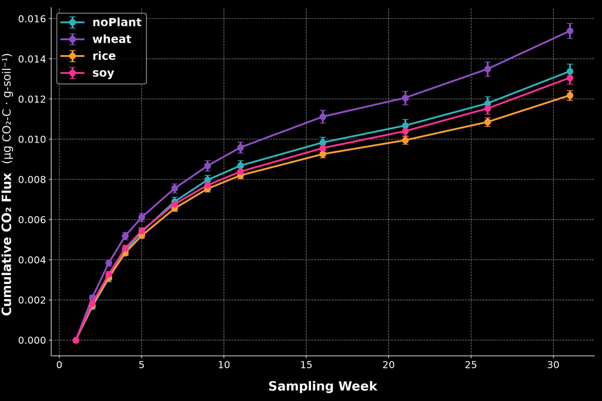

```python
# Cumulative CO2 Flux Analysis - Grouped by Crop (Trapezoidal Rule Integration)
import pandas as pd
import matplotlib.pyplot as plt
import numpy as np

# Define the path to your Excel file
excel_path = "../CO2 data/Compiled_CO2_data.xlsx"

# Function to calculate cumulative flux using trapezoidal rule
def trapezoidal_integration(weeks, fluxes, sems):
    """
    Calculate cumulative integrated flux using trapezoidal rule.

    Args:
        weeks: array of sampling week numbers (time points)
        fluxes: array of flux values at each time point
        sems: array of standard errors at each time point

    Returns:
        cumulative_flux: array of integrated flux values
        cumulative_sem: array of error estimates for integrated flux
    """
    n = len(weeks)
    cumulative_flux = np.zeros(n)
    cumulative_var = np.zeros(n)  # Variance accumulator for error propagation

    for i in range(1, n):
        # Calculate time interval (in weeks)
        delta_t = weeks[i] - weeks[i-1]

        # Trapezoidal rule: Area = (y_i + y_{i+1})/2 * Δt
        trap_area = (fluxes[i-1] + fluxes[i]) / 2.0 * delta_t
        cumulative_flux[i] = cumulative_flux[i-1] + trap_area

        # Error propagation for trapezoidal integration
        # var(Area) = (Δt/2)^2 * (sem_{i-1}^2 + sem_i^2)
        trap_var = ((delta_t / 2.0) ** 2) * (sems[i-1] ** 2 + sems[i] ** 2)
        cumulative_var[i] = cumulative_var[i-1] + trap_var

    cumulative_sem = np.sqrt(cumulative_var)

    return cumulative_flux, cumulative_sem

# Calculate cumulative flux using trapezoidal rule for each crop
crops = df_clean['crop'].unique()
weekly_averages = {}

for crop in crops:
    crop_data = df_clean[df_clean['crop'] == crop]
    weeks = sorted(crop_data['sampling_wk'].unique())
    weekly_avg_list = []
    weekly_sem_list = []
    weekly_n_list = []

    for week in weeks:
        week_data = crop_data[crop_data['sampling_wk'] == week]['Flux (μg CO2-C/g-soil/minute)']
        if len(week_data) > 0:
            weekly_avg = week_data.mean()
            weekly_sem = week_data.sem()
            weekly_n = len(week_data)
        else:
            weekly_avg = np.nan
            weekly_sem = np.nan
            weekly_n = 0
        weekly_avg_list.append(weekly_avg)
        weekly_sem_list.append(weekly_sem)
        weekly_n_list.append(weekly_n)

    # Use trapezoidal rule for integration
    cumulative_flux, cumulative_sem = trapezoidal_integration(
        np.array(weeks),
        np.array(weekly_avg_list),
        np.array(weekly_sem_list)
    )

    weekly_averages[crop] = {
        'weeks': weeks,
        'weekly_flux': weekly_avg_list,
        'weekly_sem': weekly_sem_list,
        'weekly_n': weekly_n_list,
        'cumulative_flux': cumulative_flux,
        'cumulative_sem': cumulative_sem,
        'cumulative_n': np.cumsum(weekly_n_list)
    }

# Print summary of weekly averages in order of suberin content
crop_order = ['noPlant', 'wheat', 'rice', 'soy']
print("Weekly Average CO2 Flux (no outlier filtering):")
print("Cumulative values calculated via trapezoidal rule integration\n")
for crop in crop_order:
    if crop in weekly_averages:
        print(f"{crop}:")
        for i, week in enumerate(weekly_averages[crop]['weeks']):
            print(f"  Week {week}: {weekly_averages[crop]['weekly_flux'][i]:.2f} μg CO2-C/g-soil/minute (n={weekly_averages[crop]['weekly_n'][i]})")

# Create cumulative flux visualization
fig, ax = plt.subplots(figsize=(12, 8))

# Define colors for noPlant, wheat, rice, soy
crop_order = ['noPlant', 'wheat', 'rice', 'soy']
colors = ['#2fb1b9', '#8c4dc3', '#FC9D33', '#FE318E']  # aqua, purple, orange, pink

# Plot cumulative flux for each crop with error bars
for i, crop in enumerate(crop_order):
    if crop in weekly_averages:
        weeks = weekly_averages[crop]['weeks']
        cumulative = weekly_averages[crop]['cumulative_flux']
        cumulative_sem = weekly_averages[crop]['cumulative_sem']
        plt.errorbar(weeks, cumulative, yerr=cumulative_sem, marker='o', linestyle='-', linewidth=2.6,
                    markersize=8.5, label=f'{crop}', color=colors[i], capsize=4.5);

plt.xlabel('Sampling Week', fontsize=18, weight='bold', labelpad=15);
# Create custom ylabel with different formatting - moved closer to plot
ax.text(-0.08, 0.32, 'Cumulative CO₂ Flux', transform=ax.transAxes, rotation=90,
        fontsize=18, weight=690, ha='center', va='center')
ax.text(-0.08, 0.71, '(μg CO₂-C · g-soil⁻¹)', transform=ax.transAxes, rotation=90,
        fontsize=16, weight=550, ha='center', va='center')
plt.tick_params(axis='both', which='major', labelsize=14);
plt.grid(True, linestyle='--', alpha=0.48);
plt.legend(prop={'weight': 565, 'size': 16});

# Add some styling
ax.spines['top'].set_visible(False)
ax.spines['right'].set_visible(False)
plt.tight_layout()

# Save the figure
plots_folder = os.path.join(box_base, "Salk Institute Project/AKS Salk files/CO2 data/Plots/")
plt.savefig(os.path.join(plots_folder, 'jars_cumul_co2_flux_by_crop_no_filter-dark.png'), dpi=300, bbox_inches='tight')
print(f"\nCumulative flux plot saved to 'jars_cumul_co2_flux_by_crop_no_filter-dark.png'")

# Display final cumulative values
print("\nFinal Cumulative CO2 Flux Values (Trapezoidal Integration):")
for crop in crop_order:
    if crop in weekly_averages:
        final_cumulative = weekly_averages[crop]['cumulative_flux'][-1]
        final_sem = weekly_averages[crop]['cumulative_sem'][-1]
        n = weekly_averages[crop]['cumulative_n'][-1]
        print(f"{crop.capitalize()}: {final_cumulative:.2f} ± {final_sem:.2f} μg CO2-C/g-soil (n={n})")

plt.show()
```

### Cumulative flux with outlier filtering

Filters out values beyond 1 standard deviation from the mean for that week, recalculates weekly averages, and plots the resulting cumulative flux over time.

```
> Weekly Average CO2 Flux (after outlier filtering):
> Cumulative values calculated via trapezoidal rule integration
> noPlant:
>   Week 1: 0.00 μg CO2-C/g-soil/minute (n=12)
>   Week 2: 0.00 μg CO2-C/g-soil/minute (n=8)
>   Week 3: 0.00 μg CO2-C/g-soil/minute (n=8)
>   Week 4: 0.00 μg CO2-C/g-soil/minute (n=8)
>   Week 5: 0.00 μg CO2-C/g-soil/minute (n=8)
>   Week 7: 0.00 μg CO2-C/g-soil/minute (n=8)
>   Week 9: 0.00 μg CO2-C/g-soil/minute (n=8)
>   Week 11: 0.00 μg CO2-C/g-soil/minute (n=8)
>   Week 16: 0.00 μg CO2-C/g-soil/minute (n=6)
>   Week 21: 0.00 μg CO2-C/g-soil/minute (n=7)
>   Week 26: 0.00 μg CO2-C/g-soil/minute (n=2)
>   Week 31: 0.00 μg CO2-C/g-soil/minute (n=2)
> wheat:
>   Week 1: 0.00 μg CO2-C/g-soil/minute (n=12)
>   Week 2: 0.00 μg CO2-C/g-soil/minute (n=6)
>   Week 3: 0.00 μg CO2-C/g-soil/minute (n=8)
>   Week 4: 0.00 μg CO2-C/g-soil/minute (n=8)
>   Week 5: 0.00 μg CO2-C/g-soil/minute (n=10)
>   Week 7: 0.00 μg CO2-C/g-soil/minute (n=7)
>   Week 9: 0.00 μg CO2-C/g-soil/minute (n=11)
>   Week 11: 0.00 μg CO2-C/g-soil/minute (n=11)
>   Week 16: 0.00 μg CO2-C/g-soil/minute (n=5)
>   Week 21: 0.00 μg CO2-C/g-soil/minute (n=6)
>   Week 26: 0.00 μg CO2-C/g-soil/minute (n=2)
>   Week 31: 0.00 μg CO2-C/g-soil/minute (n=3)
> rice:
>   Week 1: 0.00 μg CO2-C/g-soil/minute (n=21)
>   Week 2: 0.00 μg CO2-C/g-soil/minute (n=17)
>   Week 3: 0.00 μg CO2-C/g-soil/minute (n=15)
>   Week 4: 0.00 μg CO2-C/g-soil/minute (n=14)
>   Week 5: 0.00 μg CO2-C/g-soil/minute (n=14)
>   Week 7: 0.00 μg CO2-C/g-soil/minute (n=17)
>   Week 9: 0.00 μg CO2-C/g-soil/minute (n=16)
>   Week 11: 0.00 μg CO2-C/g-soil/minute (n=19)
>   Week 16: 0.00 μg CO2-C/g-soil/minute (n=11)
>   Week 21: 0.00 μg CO2-C/g-soil/minute (n=13)
>   Week 26: 0.00 μg CO2-C/g-soil/minute (n=6)
>   Week 31: 0.00 μg CO2-C/g-soil/minute (n=4)
> soy:
>   Week 1: 0.00 μg CO2-C/g-soil/minute (n=21)
>   Week 2: 0.00 μg CO2-C/g-soil/minute (n=18)
>   Week 3: 0.00 μg CO2-C/g-soil/minute (n=19)
>   Week 4: 0.00 μg CO2-C/g-soil/minute (n=15)
>   Week 5: 0.00 μg CO2-C/g-soil/minute (n=18)
>   Week 7: 0.00 μg CO2-C/g-soil/minute (n=15)
>   Week 9: 0.00 μg CO2-C/g-soil/minute (n=19)
>   Week 11: 0.00 μg CO2-C/g-soil/minute (n=16)
>   Week 16: 0.00 μg CO2-C/g-soil/minute (n=11)
>   Week 21: 0.00 μg CO2-C/g-soil/minute (n=15)
>   Week 26: 0.00 μg CO2-C/g-soil/minute (n=6)
>   Week 31: 0.00 μg CO2-C/g-soil/minute (n=5)
>
> Cumulative flux plot saved to 'jars_cumul_co2_flux_by_crop_filtered.png'
>
> Final Cumulative CO2 Flux Values (Trapezoidal Integration):
> Noplant: 0.01 ± 0.00 μg CO2-C/g-soil (n=85)
> Wheat: 0.01 ± 0.00 μg CO2-C/g-soil (n=89)
> Rice: 0.01 ± 0.00 μg CO2-C/g-soil (n=167)
> Soy: 0.01 ± 0.00 μg CO2-C/g-soil (n=178)
```

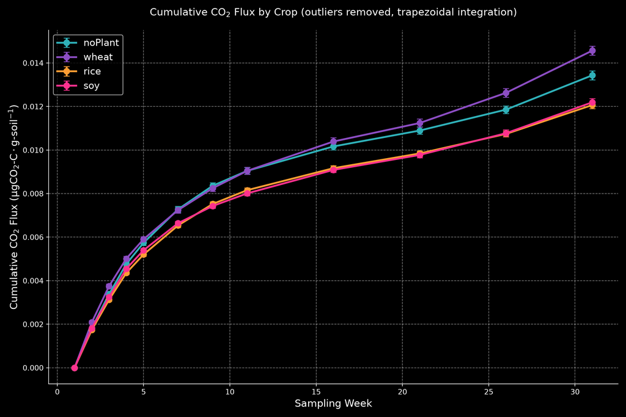

```python
# Cumulative CO2 Flux Analysis - Grouped by Crop (Trapezoidal Rule Integration)
import pandas as pd
import matplotlib.pyplot as plt
import numpy as np

# Define the path to your Excel file
excel_path = "../CO2 data/Compiled_CO2_data.xlsx"

# Function to filter outliers (values beyond 1 standard deviation)
def filter_outliers(data):
    """Remove values beyond 1 standard deviation from the mean"""
    mean = data.mean()
    std = data.std()
    return data[(data >= mean - std) & (data <= mean + std)]

# Function to calculate cumulative flux using trapezoidal rule
def trapezoidal_integration(weeks, fluxes, sems):
    """
    Calculate cumulative integrated flux using trapezoidal rule.

    Args:
        weeks: array of sampling week numbers (time points)
        fluxes: array of flux values at each time point
        sems: array of standard errors at each time point

    Returns:
        cumulative_flux: array of integrated flux values
        cumulative_sem: array of error estimates for integrated flux
    """
    n = len(weeks)
    cumulative_flux = np.zeros(n)
    cumulative_var = np.zeros(n)  # Variance accumulator for error propagation

    for i in range(1, n):
        # Calculate time interval (in weeks)
        delta_t = weeks[i] - weeks[i-1]

        # Trapezoidal rule: Area = (y_i + y_{i+1})/2 * Δt
        trap_area = (fluxes[i-1] + fluxes[i]) / 2.0 * delta_t
        cumulative_flux[i] = cumulative_flux[i-1] + trap_area

        # Error propagation for trapezoidal integration
        # var(Area) = (Δt/2)^2 * (sem_{i-1}^2 + sem_i^2)
        trap_var = ((delta_t / 2.0) ** 2) * (sems[i-1] ** 2 + sems[i] ** 2)
        cumulative_var[i] = cumulative_var[i-1] + trap_var

    cumulative_sem = np.sqrt(cumulative_var)

    return cumulative_flux, cumulative_sem

# Calculate cumulative flux using trapezoidal rule for each crop
crops = df_clean['crop'].unique()
weekly_averages = {}

for crop in crops:
    crop_data = df_clean[df_clean['crop'] == crop]
    weeks = sorted(crop_data['sampling_wk'].unique())
    weekly_avg_list = []
    weekly_sem_list = []
    weekly_n_list = []

    for week in weeks:
        week_data = crop_data[crop_data['sampling_wk'] == week]['Flux (μg CO2-C/g-soil/minute)']
        filtered_data = filter_outliers(week_data)
        n_filtered = len(filtered_data)
        if n_filtered > 0:
            weekly_avg = filtered_data.mean()
            weekly_sem = filtered_data.sem()
        else:
            weekly_avg = week_data.mean()
            weekly_sem = week_data.sem()
        weekly_avg_list.append(weekly_avg)
        weekly_sem_list.append(weekly_sem)
        weekly_n_list.append(n_filtered)

    # Use trapezoidal rule for integration
    cumulative_flux, cumulative_sem = trapezoidal_integration(
        np.array(weeks),
        np.array(weekly_avg_list),
        np.array(weekly_sem_list)
    )

    weekly_averages[crop] = {
        'weeks': weeks,
        'weekly_flux': weekly_avg_list,
        'weekly_sem': weekly_sem_list,
        'weekly_n': weekly_n_list,
        'cumulative_flux': cumulative_flux,
        'cumulative_sem': cumulative_sem,
        'cumulative_n': np.cumsum(weekly_n_list)
    }

# Print summary of weekly averages in order of suberin content
crop_order = ['noPlant', 'wheat', 'rice', 'soy']
print("Weekly Average CO2 Flux (after outlier filtering):")
print("Cumulative values calculated via trapezoidal rule integration\n")
for crop in crop_order:
    if crop in weekly_averages:
        print(f"{crop}:")
        for i, week in enumerate(weekly_averages[crop]['weeks']):
            avg = weekly_averages[crop]['weekly_flux'][i]
            n = weekly_averages[crop]['weekly_n'][i]
            print(f"  Week {week}: {avg:.2f} μg CO2-C/g-soil/minute (n={n})")

# Create cumulative flux visualization
fig, ax = plt.subplots(figsize=(12, 8))

# Define colors for noPlant, wheat, rice, soy
crop_order = ['noPlant', 'wheat', 'rice', 'soy']
colors = ['#2fb1b9', '#8c4dc3', '#FC9D33', '#FE318E']  # aqua, purple, orange, pink

# Plot cumulative flux for each crop WITH error bars
for i, crop in enumerate(crop_order):
    if crop in weekly_averages:
        weeks = weekly_averages[crop]['weeks']
        cumulative = weekly_averages[crop]['cumulative_flux']
        cumulative_sem = weekly_averages[crop]['cumulative_sem']
        plt.errorbar(weeks, cumulative, yerr=cumulative_sem, marker='o', linestyle='-', linewidth=2.5,
                    markersize=8, label=f'{crop}', color=colors[i], capsize=4);

plt.xlabel('Sampling Week', fontsize=14);
plt.ylabel(r'Cumulative $\mathrm{CO_2}$ Flux $\mathrm{(μg CO_2}$-$\mathrm{C \cdot g}$-$\mathrm{soil^{-1})}$', fontsize=14);
plt.title('Cumulative $\mathrm{CO_2}$ Flux by Crop (outliers removed, trapezoidal integration)', fontsize=14, pad=20);
plt.grid(True, linestyle='--', alpha=0.48);
plt.legend(fontsize=13);

# Add some styling
ax.spines['top'].set_visible(False)
ax.spines['right'].set_visible(False)
plt.tight_layout()

# Save the figure
plt.savefig(os.path.join(plots_folder, 'jars_cumul_co2_flux_by_crop_filtered.png'), dpi=300, bbox_inches='tight')
print(f"\nCumulative flux plot saved to 'jars_cumul_co2_flux_by_crop_filtered.png'")

# Display final cumulative values
print("\nFinal Cumulative CO2 Flux Values (Trapezoidal Integration):")
for crop in crop_order:
    if crop in weekly_averages:
        final_cumulative = weekly_averages[crop]['cumulative_flux'][-1]
        final_sem = weekly_averages[crop]['cumulative_sem'][-1]
        n = weekly_averages[crop]['cumulative_n'][-1]
        print(f"{crop.capitalize()}: {final_cumulative:.2f} ± {final_sem:.2f} μg CO2-C/g-soil (n={n})")

plt.show()
```

## Decay rate (k)

The following code estimates an apparent first-order decay constant for each crop using the cumulative CO<sub>2</sub>-C loss and the crop-level starting total carbon stock. The formula is $k = -\ln(C_t / C_0) / t$, where $C_0$ is the mean `est-total-C_mg` for that crop, $C_t = C_0 - \mathrm{cumulative\ CO_2\text{-}C}$, and $t$ is time in days since the start of the incubation.

The `dry_soil_g` column is now available in the `Jars` tab, but the current flux values are still normalized per g soil, so the decay calculation stays on this apparent basis. The `initial_mass_mg` values in the factor tables are root material added, not jar soil mass, so they are not used here.

```python
import numpy as np
import pandas as pd

flux_col = 'Flux (μg CO2-C/g-soil/minute)'
required_cols = ['crop', 'sampling_wk', 'est-total-C_mg', flux_col]
missing_cols = [col for col in required_cols if col not in df.columns]

if missing_cols:
    raise ValueError(f"Missing required columns for decay-rate calculation: {missing_cols}")

crop_decay = df.dropna(subset=required_cols).copy()
crop_decay['sampling_wk'] = pd.to_numeric(crop_decay['sampling_wk'], errors='coerce')
crop_decay = crop_decay.dropna(subset=['sampling_wk'])

crop_levels = []
for crop, group in crop_decay.groupby('crop'):
    group = group.sort_values('sampling_wk').copy()
    weeks = group['sampling_wk'].drop_duplicates().to_numpy(dtype=float)
    if len(weeks) == 0:
        continue

    weekly_flux = []
    for week in weeks:
        weekly_flux.append(group.loc[group['sampling_wk'] == week, flux_col].mean())

    cumulative_flux = np.zeros(len(weeks), dtype=float)
    for i in range(1, len(weeks)):
        delta_weeks = weeks[i] - weeks[i - 1]
        cumulative_flux[i] = cumulative_flux[i - 1] + ((weekly_flux[i - 1] + weekly_flux[i]) / 2.0) * delta_weeks

    initial_C_mg = group['est-total-C_mg'].mean()
    elapsed_days = (weeks - weeks.min()) * 7.0
    remaining_C_mg = initial_C_mg - cumulative_flux

    valid_mask = (
        (elapsed_days > 0) &
        (remaining_C_mg > 0) &
        (remaining_C_mg < initial_C_mg)
    )
    k_per_day = np.full(len(weeks), np.nan, dtype=float)
    k_per_day[valid_mask] = -np.log(remaining_C_mg[valid_mask] / initial_C_mg) / elapsed_days[valid_mask]

    crop_levels.append(pd.DataFrame({
        'crop': crop,
        'sampling_wk': weeks,
        'elapsed_days': elapsed_days,
        'initial_C_mg': initial_C_mg,
        'weekly_flux_mean': weekly_flux,
        'cumulative_flux_proxy': cumulative_flux,
        'remaining_C_mg': remaining_C_mg,
        'k_per_day': k_per_day,
        'k_per_week': k_per_day * 7.0,
    }))

crop_k = pd.concat(crop_levels, ignore_index=True) if crop_levels else pd.DataFrame()

valid_k = crop_k['k_per_day'].dropna() if not crop_k.empty else pd.Series(dtype=float)
print("Apparent decay-rate calculation:")
print(f"Rows processed: {len(crop_k)}")
print(f"Valid k estimates: {len(valid_k)}")

if len(valid_k) > 0:
    print("\nSummary of k values (per day):")
    print(valid_k.describe().to_string())
else:
    print("\nNo valid k values were found. That usually means the cumulative flux exceeds the starting carbon stock on the current unit basis.")

print("\nPer-crop k preview:")
print(crop_k[['crop', 'sampling_wk', 'initial_C_mg', 'cumulative_flux_proxy', 'remaining_C_mg', 'elapsed_days', 'k_per_day', 'k_per_week']].head(10).to_string())

try:
    with pd.ExcelWriter(excel_path, engine='openpyxl', mode='a', if_sheet_exists='replace') as writer:
        crop_k.to_excel(writer, sheet_name='Crop_decay_k', index=False)
    print("\nDecay-rate table saved to 'Crop_decay_k' tab in the existing Excel file")
except Exception as e:
    print(f"\nError saving decay-rate table to Excel file: {e}")
```

```
> Apparent decay-rate calculation:
> Rows processed: 48
> Valid k estimates: 44
>
> Summary of k values (per day):
> count    4.400000e+01
> mean     5.415335e-08
> std      2.519483e-08
> min      2.085354e-08
> 25%      3.015535e-08
> 50%      5.052931e-08
> 75%      7.688234e-08
> max      1.087095e-07
>
> Per-crop k preview:
>       crop  sampling_wk  initial_C_mg  cumulative_flux_proxy  remaining_C_mg  elapsed_days     k_per_day    k_per_week
> 0  noPlant          1.0   2763.384984               0.000000     2763.384984           0.0           NaN           NaN
> 1  noPlant          2.0   2763.384984               0.001664     2763.383320           7.0  8.603254e-08  6.022278e-07
> 2  noPlant          3.0   2763.384984               0.003074     2763.381910          14.0  7.945058e-08  5.561540e-07
> 3  noPlant          4.0   2763.384984               0.004433     2763.380551          21.0  7.639140e-08  5.347398e-07
> 4  noPlant          5.0   2763.384984               0.005385     2763.379600          28.0  6.959125e-08  4.871387e-07
> 5  noPlant          7.0   2763.384984               0.006893     2763.378091          42.0  5.939237e-08  4.157466e-07
> 6  noPlant          9.0   2763.384984               0.007969     2763.377016          56.0  5.149332e-08  3.604533e-07
> 7  noPlant         11.0   2763.384984               0.008684     2763.376300          70.0  4.489527e-08  3.142669e-07
> 8  noPlant         16.0   2763.384984               0.009836     2763.375148         105.0  3.389972e-08  2.372980e-07
> 9  noPlant         21.0   2763.384984               0.010677     2763.374307         140.0  2.759786e-08  1.931850e-07
>
> Error saving decay-rate table to Excel file: [Errno 2] No such file or directory: '../CO2 data/Compiled_CO2_data.xlsx'
```

# Pot data

## Reading data & summarizing

The following code cell loads data from an excel file and generates summary statistics (mean, standard deviation, minimum, maximum and count), grouped by crop, isotope and sampling week for δ<sup>13</sup>C<sub>VPDB</sub> (‰), at-% <sup>13</sup>C, CO<sub>2</sub> (ppm), and flux (μg CO<sub>2</sub>-C ⋅ cm[V/A]<sup>-1</sup> ⋅ minute<sup>-1</sup>). It saves these statistics as a new tab, “Pots_Summary_Stats”, in the spreadsheet “Compiled_CO2_data.xlsx”.

```python
import pandas as pd
import matplotlib.pyplot as plt
import seaborn as sns
import numpy as np
import openpyxl
import os
box_base = os.environ.get('BOX_BASE')
if box_base is None:
    raise ValueError("BOX_BASE environment variable is not set!")

excel_path = os.path.join(box_base, "Salk Institute Project/AKS Salk files/CO2 data/Compiled_CO2_data.xlsx")

# Read the 'Pots' tab from the Excel file
try:
    df1 = pd.read_excel(excel_path, sheet_name='Pots')
    print("Excel file loaded successfully!")
except Exception as e:
    print(f"Error loading Excel file: {e}")
    import sys
    sys.exit(1)

# # Display the first few rows to verify data
# print("\nFirst 5 rows of the dataframe:")
# print(df1.head())

# # Check column names
# print("\nColumn names:")
# print(df1.columns.tolist())

# Convert isotope to integer format (removing decimals)
df1['isotope'] = df1['isotope'].fillna(-1)  # Replace NaN with -1 temporarily
df1['isotope'] = df1['isotope'].astype(int)  # Convert to integer
df1.loc[df1['isotope'] == -1, 'isotope'] = np.nan  # Convert -1 back to NaN if needed

# Remove rows with NaN values in key columns
columns_to_analyze = ['δ13CVPDB (‰)', 'at-% 13C', 'CO2 (ppm) - Blank', 'Flux (μg CO2-C/cm[V/A]/minute)']
df1_clean = df1.dropna(subset=['crop', 'isotope', 'sampling_wk'] + columns_to_analyze)

# print(f"\nRemoved {len(df1) - len(df1_clean)} rows with NaN values")
# print(f"Remaining rows: {len(df1_clean)}")

# Generate summary statistics grouped by crop, isotope, and sampling_wk
summary_stats1 = df1_clean.groupby(['crop', 'isotope', 'sampling_wk'])[columns_to_analyze].agg(
    ['mean', 'std', 'min', 'max', 'count']
)

# Save the summary statistics to a new tab in the existing Excel file
try:
    with pd.ExcelWriter(excel_path, engine='openpyxl', mode='a', if_sheet_exists='replace') as writer:
        summary_stats1.to_excel(writer, sheet_name='Pots_Summary_Stats')
    print("\nSummary statistics saved to 'Pots_Summary_Stats' tab in the existing Excel file")
except Exception as e:
    print(f"Error saving to Excel file: {e}")

# Print a preview of the summary statistics
print("\nSummary Statistics Preview:")
print(summary_stats1.head())
```

```
> Excel file loaded successfully!
>
> Summary statistics saved to 'Pots_Summary_Stats' tab in the existing Excel file
>
> Summary Statistics Preview:
>                             δ13CVPDB (‰)             ... Flux (μg CO2-C/cm[V/A]/minute)
>                                     mean        std  ...                            max count
> crop    isotope sampling_wk                          ...
> noPlant 12.0    30            -11.745726   0.681702  ...                       3.924127     3
>                 40            -12.286841   0.505217  ...                       1.363547     3
>         13.0    30            -11.399520   0.022676  ...                       3.161349     2
>                 40             -8.599702   1.603134  ...                      -1.495311     3
> rice    13.0    10              8.650592  24.682512  ...                      57.600634     3
>
> [5 rows x 20 columns]
```

## Plotting δ<sup>13</sup>C & CO<sub>2</sub> flux (pots)

The following code plots δ<sup>13</sup>C<sub>VPDB</sub> (‰) vs Sampling week and Flux (μg CO<sub>2</sub>-C ⋅ cm[V/A]<sup>-1</sup> ⋅ minute<sup>-1</sup>) vs Sampling week as subplots on one figure. It saves the figure as a PNG file called “pots_analysis_plots_VPDB”.

```
>
> Plots saved to 'pots_analysis_plots_VPDB.png'
```

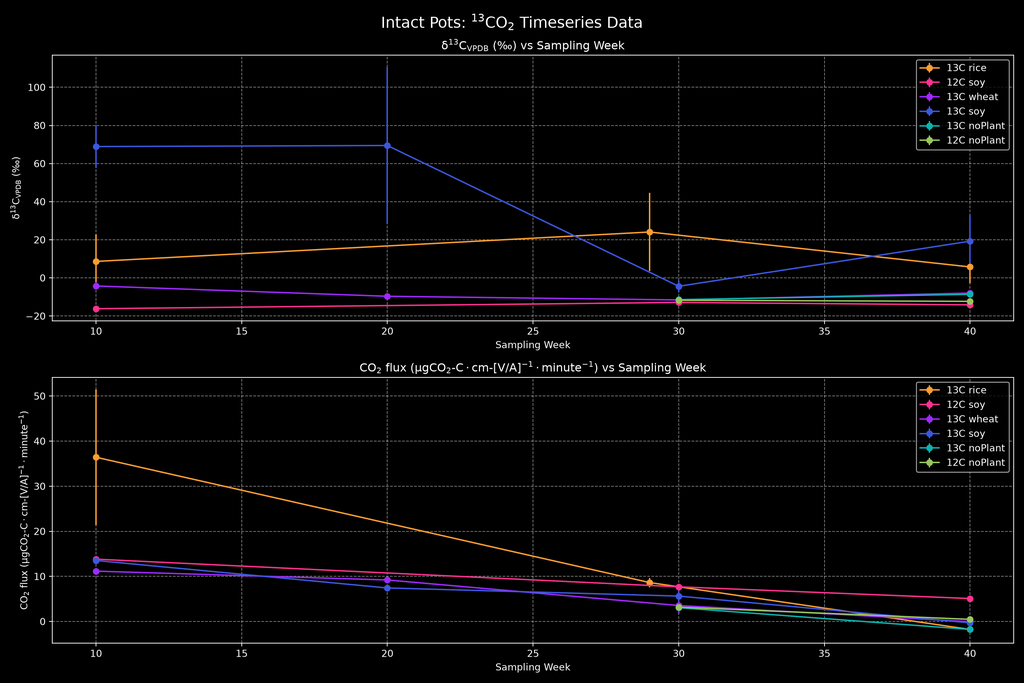

```python
import pandas as pd
import matplotlib.pyplot as plt
import seaborn as sns
import numpy as np

# Create figure for plotting
fig2=plt.figure(figsize=(15, 10))
fig2.suptitle(r'Intact Pots: $\mathrm{^{13}CO_{2}}$ Timeseries Data', fontsize=16);
# Get unique combinations of crop and isotope
crop_isotope_combinations1 = df1_clean[['crop', 'isotope']].drop_duplicates()

# Create a color palette for consistent colors across plots
# Use a different approach with a simple list of colors
#num_combinations = len(crop_isotope_combinations)
#colors = sns.color_palette('husl', num_combinations)
colors1 = ['#FC9D33', '#FE318E', '#9F29FF','#3C57DE','#0CB2AF', '#98C65D']   # orange, pink, purple, blue, teal, green


# Creating Plot 1: δ13CVPDB (‰) vs sampling_week
plt.subplot(2, 1, 1);

# Plot each crop & root_isotope combination as a separate series
for i, (_, row) in enumerate(crop_isotope_combinations1.iterrows()):
    crop = row['crop']
    isotope = int(row['isotope'])  # Convert to integer to remove decimal

    # Filter data for this combination
    subset = df1_clean[(df1_clean['crop'] == crop) & (df1_clean['isotope'] == isotope)]

    # Calculate mean and standard error for each sampling_wk
    grouped = subset.groupby('sampling_wk')['δ13CVPDB (‰)'].agg(['mean', 'sem']).reset_index()

    # Plot the mean values with predefined color from index
    plt.errorbar(grouped['sampling_wk'], grouped['mean'], yerr=grouped['sem'],
                 marker='o', linestyle='-', label=f"{isotope}C {crop}", color=colors1[i]);

plt.xlabel('Sampling Week');
plt.ylabel(r'$\mathrm{δ^{13}C_{VPDB}}$ (‰)');
plt.title(r'$\mathrm{δ^{13}C_{VPDB}}$ (‰) vs Sampling Week');
plt.grid(True, linestyle='--', alpha=0.48);
plt.legend();

# Creating Plot 2: Flux (μg CO2-C/cm[V/A]/minute) vs sampling_wk
plt.subplot(2, 1, 2);

# Plot each crop & isotope combination as a separate series
for i, (_, row) in enumerate(crop_isotope_combinations1.iterrows()):
    crop = row['crop']
    isotope = int(row['isotope'])  # Convert to integer to remove decimal

    # Filter data for this combination
    subset = df1_clean[(df1_clean['crop'] == crop) & (df1_clean['isotope'] == isotope)]

    # Calculate mean and standard error for each sampling_wk
    grouped = subset.groupby('sampling_wk')['Flux (μg CO2-C/cm[V/A]/minute)'].agg(['mean', 'sem']).reset_index()

    # Plot the mean values with predefined color from index
    plt.errorbar(grouped['sampling_wk'], grouped['mean'], yerr=grouped['sem'],
                 marker='o', linestyle='-', label=f"{isotope}C {crop}", color=colors1[i]);

plt.xlabel('Sampling Week');
plt.ylabel(r'$\mathrm{CO_2}$ flux $\mathrm{(μg CO_2}$-$\mathrm{C \cdot cm}$-$\mathrm{[V/A]^{-1} \cdot minute^{-1}})$');
plt.title(r'$\mathrm{CO_2}$ flux $\mathrm{(μg CO_2}$-$\mathrm{C \cdot cm}$-$\mathrm{[V/A]^{-1} \cdot minute^{-1}})$ vs Sampling Week');
plt.grid(True, linestyle='--', alpha=0.48);
plt.legend();

# Adjust layout and save figure
plt.tight_layout()
plots_folder = os.path.join(box_base, "Salk Institute Project/AKS Salk files/CO2 data/Plots/")
plt.savefig(os.path.join(plots_folder, 'pots_analysis_plots_VPDB.png'), dpi=300)
print("\nPlots saved to 'pots_analysis_plots_VPDB.png'")

# Show the plots
plt.show()
```

## Plotting atom % <sup>13</sup>C & CO<sub>2</sub> flux (pots)

The following code plots atom % <sup>13</sup>C vs Sampling week and Flux (μg CO<sub>2</sub>-C ⋅ cm[V/A]<sup>-1</sup> ⋅ minute<sup>-1</sup>) vs Sampling week as subplots on one figure. It saves the figure as a PNG file called “pots_analysis_plots_at-pct”. I wrote this after noticing that JP presents isotope data in atom % rather than δ<sup>13</sup>C<sub>VPDB</sub> (‰).

```
>
> Plots saved to 'pots_analysis_plots_at-pct.png'
```

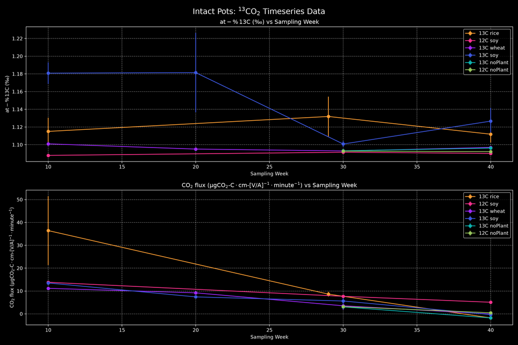

```python
import pandas as pd
import matplotlib.pyplot as plt
import seaborn as sns
import numpy as np

# Create figure for plotting
fig3=plt.figure(figsize=(15, 10))
fig3.suptitle(r'Intact Pots: $\mathrm{^{13}CO_{2}}$ Timeseries Data', fontsize=16);
# Get unique combinations of crop and isotope
crop_isotope_combinations1 = df1_clean[['crop', 'isotope']].drop_duplicates()

# Create a color palette for consistent colors across plots
# Use a different approach with a simple list of colors
#num_combinations = len(crop_isotope_combinations)
#colors = sns.color_palette('husl', num_combinations)
colors1 = ['#FC9D33', '#FE318E', '#9F29FF','#3C57DE','#0CB2AF', '#98C65D']   # orange, pink, purple, blue, teal, green


# Creating Plot 1: at-% 13C vs sampling_week
plt.subplot(2, 1, 1);

# Plot each crop & root_isotope combination as a separate series
for i, (_, row) in enumerate(crop_isotope_combinations1.iterrows()):
    crop = row['crop']
    isotope = int(row['isotope'])  # Convert to integer to remove decimal

    # Filter data for this combination
    subset = df1_clean[(df1_clean['crop'] == crop) & (df1_clean['isotope'] == isotope)]

    # Calculate mean and standard error for each sampling_wk
    grouped = subset.groupby('sampling_wk')['at-% 13C'].agg(['mean', 'sem']).reset_index()

    # Plot the mean values with predefined color from index
    plt.errorbar(grouped['sampling_wk'], grouped['mean'], yerr=grouped['sem'],
                 marker='o', linestyle='-', label=f"{isotope}C {crop}", color=colors1[i]);

plt.xlabel('Sampling Week');
plt.ylabel(r'$\mathrm{at-\% \, 13C}$ (‰)');
plt.title(r'$\mathrm{at-\% \, 13C}$ (‰) vs Sampling Week');
plt.grid(True, linestyle='--', alpha=0.48);
plt.legend();

# Creating Plot 2: Flux (μg CO2-C/cm[V/A]/minute) vs sampling_wk
plt.subplot(2, 1, 2);

# Plot each crop & isotope combination as a separate series
for i, (_, row) in enumerate(crop_isotope_combinations1.iterrows()):
    crop = row['crop']
    isotope = int(row['isotope'])  # Convert to integer to remove decimal

    # Filter data for this combination
    subset = df1_clean[(df1_clean['crop'] == crop) & (df1_clean['isotope'] == isotope)]

    # Calculate mean and standard error for each sampling_wk
    grouped = subset.groupby('sampling_wk')['Flux (μg CO2-C/cm[V/A]/minute)'].agg(['mean', 'sem']).reset_index()

    # Plot the mean values with predefined color from index
    plt.errorbar(grouped['sampling_wk'], grouped['mean'], yerr=grouped['sem'],
                 marker='o', linestyle='-', label=f"{isotope}C {crop}", color=colors1[i]);

plt.xlabel('Sampling Week');
plt.ylabel(r'$\mathrm{CO_2}$ flux $\mathrm{(μg CO_2}$-$\mathrm{C \cdot cm}$-$\mathrm{[V/A]^{-1} \cdot minute^{-1}})$');
plt.title(r'$\mathrm{CO_2}$ flux $\mathrm{(μg CO_2}$-$\mathrm{C \cdot cm}$-$\mathrm{[V/A]^{-1} \cdot minute^{-1}})$ vs Sampling Week');
plt.grid(True, linestyle='--', alpha=0.48);
plt.legend();

# Adjust layout and save figure
plt.tight_layout()
plt.savefig(os.path.join(plots_folder, 'pots_analysis_plots_at-pct.png'), dpi=300)
print("\nPlots saved to 'pots_analysis_plots_at-pct.png'")

# Show the plots
plt.show()
```

## Plotting pot CO<sub>2</sub> flux by crop only

The following code plots CO<sub>2</sub> flux (μg CO<sub>2</sub>-C ⋅ cm[V/A]<sup>-1</sup> ⋅ minute<sup>-1</sup>) vs Sampling week grouped by crop only, ignoring isotope treatments. This provides a simplified view of how each crop performs overall. It really only changes noPlant and soy, the rest of the crops we only have 13C treatments.

```
>
> Plot saved to 'pots_co2_flux_by_crop.png'
```

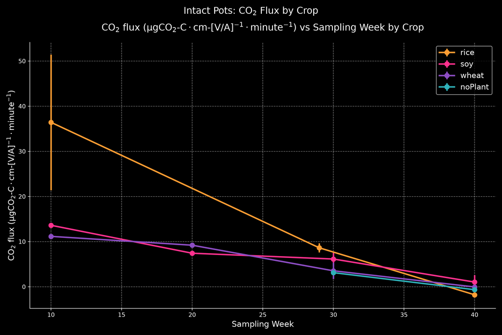

[output not shown]

[figure not shown]

```python
import pandas as pd
import matplotlib.pyplot as plt
import seaborn as sns
import numpy as np

# Create figure for plotting
fig4=plt.figure(figsize=(12, 8))
fig4.suptitle(r'Intact Pots: $\mathrm{CO_2}$ Flux by Crop', fontsize=16);

# Get unique crops
crops = df1_clean['crop'].unique()

# Define colors for crops (matching previous plots)
crop_colors = {'noPlant': '#2fb1b9', 'wheat': '#8c4dc3', 'rice': '#FC9D33', 'soy': '#FE318E'}  # aqua, purple, orange, pink

# Plot CO2 flux for each crop (ignoring isotope)
for crop in crops:
    # Filter data for this crop (all isotopes combined)
    subset = df1_clean[df1_clean['crop'] == crop]

    # Calculate mean and standard error for each sampling_wk
    grouped = subset.groupby('sampling_wk')['Flux (μg CO2-C/cm[V/A]/minute)'].agg(['mean', 'sem']).reset_index()

    # Use predefined color if available, otherwise use default
    color = crop_colors.get(crop, '#000000')

    # Plot the mean values
    plt.errorbar(grouped['sampling_wk'], grouped['mean'], yerr=grouped['sem'],
                 marker='o', linestyle='-', label=f'{crop}', color=color, linewidth=2.5, markersize=8);

plt.xlabel('Sampling Week', fontsize=14);
plt.ylabel(r'$\mathrm{CO_2}$ flux $\mathrm{(μg CO_2}$-$\mathrm{C \cdot cm}$-$\mathrm{[V/A]^{-1} \cdot minute^{-1}})$', fontsize=14);
plt.title(r'$\mathrm{CO_2}$ flux $\mathrm{(μg CO_2}$-$\mathrm{C \cdot cm}$-$\mathrm{[V/A]^{-1} \cdot minute^{-1}})$ vs Sampling Week by Crop', fontsize=16, pad=20);
plt.grid(True, linestyle='--', alpha=0.48);
plt.legend(fontsize=13);

# Add some styling
ax = plt.gca()
ax.spines['top'].set_visible(False)
ax.spines['right'].set_visible(False)

# Adjust layout and save figure
plt.tight_layout()
plt.savefig(os.path.join(plots_folder, 'pots_co2_flux_by_crop.png'), dpi=300, bbox_inches='tight')
print("\nPlot saved to 'pots_co2_flux_by_crop.png'")

# Show the plot
plt.show()
```

# Statistical Methods in Salk_CO2.Rmd

This R Markdown document employs a range of descriptive and exploratory statistical methods to analyze CO₂ flux and isotope data. Here’s a comprehensive overview:

## **Data Preparation and Cleaning**

The analysis begins with systematic data validation:

- **Missing data removal**: Rows with NaN values in key columns (δ¹³C<sub>VPDB</sub>, at-% ¹³C, CO₂ concentration, flux) are excluded
- **Type conversion**: The isotope variable is converted to integer format to maintain consistency across grouping operations
- **Validation**: Data completeness is checked across crop, isotope, and sampling week dimensions

## **Descriptive Statistics**

### Summary Statistics Tables

The document generates grouped summary statistics using:

- **Mean**: Central tendency for each measurement
- **Standard Deviation (std)**: Measure of within-group variability
- **Minimum and Maximum**: Range of observed values
- **Count (n)**: Sample size for each group
- **Grouping dimensions**: crop × isotope × sampling week

## **Uncertainty Quantification**

### Standard Error of the Mean (SEM)

Throughout all plotting sections, error bars represent the **SEM**:

$$\text{SEM} =
\frac{\sigma}{\sqrt{n}}$$

This represents the standard deviation of the sampling distribution of the mean, indicating precision of the weekly average estimates.

## **Trapezoidal Rule Numerical Integration**

This is the primary calculation method for cumulative flux analysis:

### Basic Formula

For consecutive time points, the trapezoidal approximation calculates:

$$\text{Area}_i = \frac{\text{flux}_{i-1}
+ \text{flux}_i}{2} \times \Delta t$$

where $\Delta t$ is the time interval (in weeks) between consecutive measurements.

### Cumulative Integration

The cumulative flux at time point $n$ is:

$$\text{Cumulative Flux}_n =
\sum_{i=1}^{n} \text{Area}_i$$

**Key advantage**: This method respects flux as a rate measurement and properly integrates over variable or irregular sampling intervals.

## **Error Propagation Through Integration**

Uncertainties are systematically propagated through the trapezoidal integration:

$$\text{var}(\text{Cumulative Flux}_n) =
\sum_{i=1}^{n} \left(\frac{\Delta t}{2}\right)^2 \times
(\text{sem}_{i-1}^2 + \text{sem}_i^2)$$

The cumulative standard error is then:

$$\text{SEM}_{\text{cumulative}} =
\sqrt{\text{var}(\text{Cumulative Flux}_n)}$$

This reflects how uncertainties **compound** as more measurements are integrated, assuming independence between weekly measurements.

## **Outlier Filtering Method**

An optional **1-standard-deviation filter** is applied in the outlier removal analysis:

For each week, values outside the range $[\bar{x} - \sigma, \bar{x} + \sigma]$ are excluded from recalculation of weekly statistics. This provides two versions of results:

- **Unfiltered**: All observations included
- **Filtered**: Extreme values removed to reduce influence of potential measurement errors

## **Data Grouping Strategies**

### Crop + Isotope Combinations

Used in detailed isotope plots (VPDB and at-% analyses):  
- Separates ¹³C-labeled and ¹²C-labeled treatments  
- Enables crop-specific and isotope-specific comparisons

### Crop Only

Used in simplified flux visualizations:  
- Combines all isotope treatments within each crop  
- Provides aggregate flux perspective  
- Accounts for different sample sizes between treatments

## **Summary of Analytical Approach**

The analysis is primarily **descriptive and exploratory** rather than inferential:

**Included:**

✓ Temporal flux integration via trapezoidal rule

✓ Systematic uncertainty quantification (SEM, error propagation)

✓ Data quality control (outlier detection, missing data handling)

✓ Time series visualization with error bands

**Not included:**

✗ Hypothesis testing (no p-values, t-tests, ANOVA)

✗ Confidence intervals (beyond error bars)

✗ Comparative statistical models or regression

✗ Assumptions testing (normality, homogeneity)

The analysis focuses on **characterizing temporal patterns in CO₂ flux and isotope composition across crops and treatments** while transparently representing measurement uncertainty.